# R bootcamp

(A few remarks and tips before the practical session)

# R is the best technology for doing computational science

## R has an incredible wealth of toolkits

The most famous is the [*tidyverse*](http://tidyverse.org) ecosystem for data science:

[figure not shown]

There are packages for machine learning ([Keras](https://tensorflow.rstudio.com/keras/), [Tensorflow](http://tensorflow.rstudio.com/)), spatial packages ([*sf*](https://r-spatial.github.io/sf/), [*stars*](https://r-spatial.github.io/stars/)), packages specific to research fields ([genomics](https://cran.r-project.org/web/views/Omics.html), [ecology](https://cran.r-project.org/web/views/Environmetrics.html), etc.). More than [23000](https://cran.r-project.org/web/packages/) packages total.

## R has awesome easy-to-use(!) tools for reproducibility

- [**Quarto** “authoring system”](https://quarto.org/) for writing automated reports, slides, PDF documents, etc. (our “Topic #4!”)
- [*targets*](https://docs.ropensci.org/targets/) pipelining framework (possibly the most powerful and flexible of its kind)
- [*tidyverse*](http://tidyverse.org) framework (particularly the *dplyr* R package introduced as “Topic 2/3”) is designed to facilitate building readable, easy-to-write processing pipelines
- R itself is a very powerful, flexible programming language

## The unfortunate way R is taught…

- Some slides on *“R as a calculator”* (only half joking)
- Then straight into plotting histograms and computing t-tests
  - Effectively treats computation / data science as black box
- R was first created “by statisticians for statisticians” (1991)
  - So this way of teaching R makes sense historically
- But teaching needs change in modern times:
  - Our data is larger and more complex than in 1990s
  - Reproducibility requires proper programming skills

## Challenge of teaching programming

1. Programming is a skill, not a knowledge to transfer
2. Teaching R in a lecture format would mean 3 hours of torture

**Today’s “R bootcamp” session is designed to walk you through fundamentals of R in an interactive form.**

A series of problems-solutions to develop understanding of:

- What happens behind the scenes of data-science operations.
- Which will give you tools and confidence to build “mental models”

# Still, a couple of practical tips

(Having observed how many scientists use R in practice.)

## Knowing RStudio well is like having a superpower

Don’t take it as nothing but a text editor like `Notepad`.

It’s a [starship Enterprise](https://laughingsquid.com/wp-content/uploads/2023/05/All-Enterprise-Bridges.jpg) of data science at your fingertips. It’s incredible powerful and has a lot of features.

At first it will be annoying and slower to use keyboard and not a mouse, but trust me. It will pay of in the long run.

## Read-Eval-Print Loop (REPL)

> […] the user enters expressions (rather than an entire [computer program]), the REPL evaluates them and displays the results […] – Wikipedia

### R console is a powerful REPL!

## R console is like an ultimate experimental lab equipment

R encourages a highly interactive workflow.

When I don’t understand something, some code I don’t get, etc., I always type it in the REPL to build an intuition.

Doing data analysis is like playing a detective, especially when figuring out bugs and problems.

Form a hypothesis, run a tiny bit of R code to test the hypothesis. Move forward based on the result you got.

**I see a lot of experienced PhD students writing and running long code top-to-bottom, instead of thinking methodically.**

## Built-in R help always has an answer!

All languages (and their packages) have documentation, sure.

But it’s mostly scattered on the internet, often hard to find.

**R packages have a standardized documentation inside R!**

- Every `func` has a manual page available at command `?func`

**Every single such help page describes:**

1. Basic usage of the function
2. Which optional parameters can be given
3. Description of what the function does
4. **Runnable example code (!!!)**

## These manuals are amazingly helpful

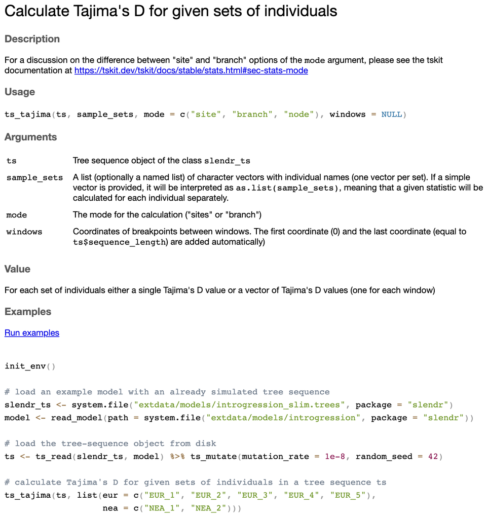

(Help for a function `ts_tajima()` from my R package.)

## Consider switching the pane layout

In the RStudio menu `Global Options` `->` `Pane Layout` set:

[figure not shown]

Maximum vertical space for code and easy switching between script and R console (particularly with keyboard shortcuts).

# Let’s get started!

1. Go to [www.bodkan.net/simgen](https://bodkan.net/simgen)
2. Click on *“R bootcamp”* in the left panel—these are the materials for this session (exercises, solutions, explanations)
3. *“Cheatsheets and handouts”* section in the left panel contains a single-page version of these slides and RStudio and base R cheatsheets for your reference
4. Open your RStudio and start working!